# Анализ анонимного зарплатного опроса исследователей Q3 2024

Сережа Розум

2025-01-09

## Небольшое введение

Это анализ датасета, собранного в летом-осенью 2024 года рамках анонимного зарплатного опроса исследователей. Ссылка на опрос рассылалась в телеграм чатах и каналах исследователей разных сфер.

Саму анкету для сбора данных можно посмотреть [тут](https://forms.gle/EdybaDFf3kXRar8E8).

Отдельное спасибо чатам и каналам, которые помогли собрать эти данные:

[figure not shown]

- Research Ops Community Russia [→](https://researchops.ru/)

[figure not shown]

- Чат Рисёрчеров [→](https://researcher-online.ru/)

[figure not shown]

- Канал “UX Horn” [→](https://t.me/uxhorn)

[figure not shown]

- Канал “Мал да удал(и)” [→](https://t.me/maldaudal_i)

[figure not shown]

- Канал “Speaking about my research” [→](https://t.me/uxresearchux)

## Как читать ящик с усами

Далее будет много графиков типа “Ящик с усами”, поэтому для вашего удобства я заранее хочу показать, как правильно такие графики читать.

Ящик с усами показывает, как распределены данные. Коробка в центре отображает основную часть значений: нижняя граница — маленькие значения (меньше, чем 75% значений), верхняя — большие (больше, чем 75% значений). Линия внутри коробки показывает середину данных (медиана). “Усы” выходят за пределы коробки и охватывают значения, которые близки к основным. Точки за пределами усов — это редкие или необычные значения.

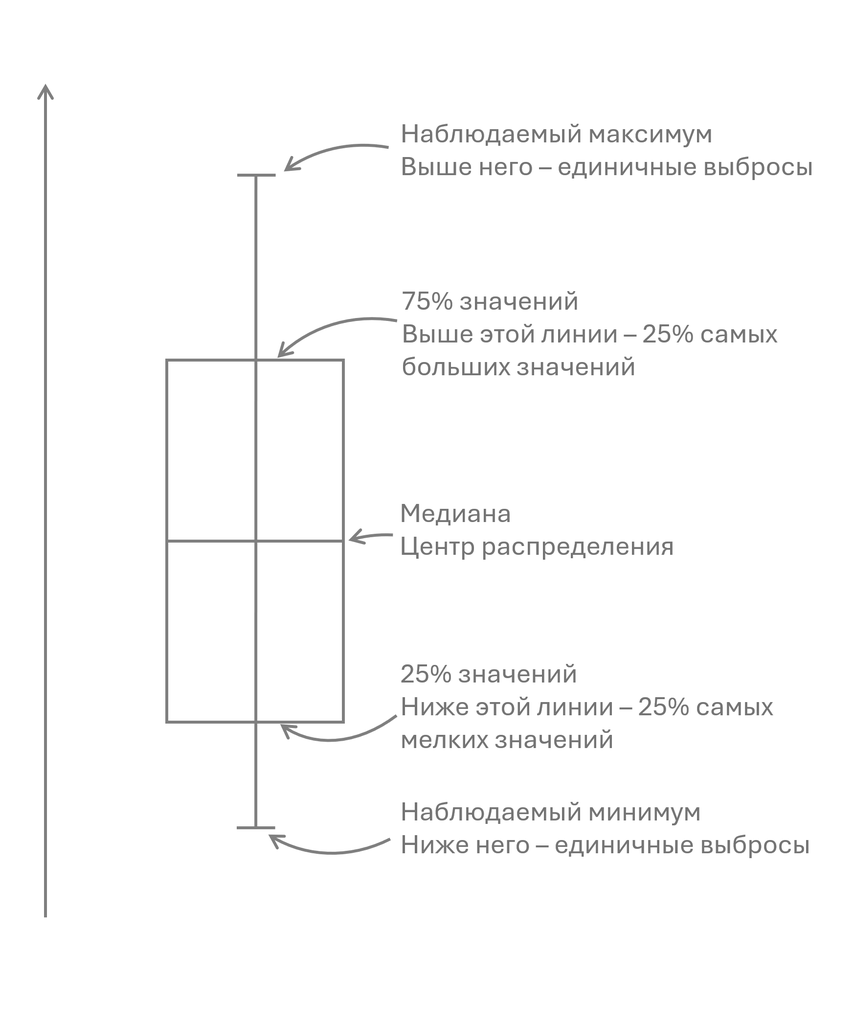

## О датасете

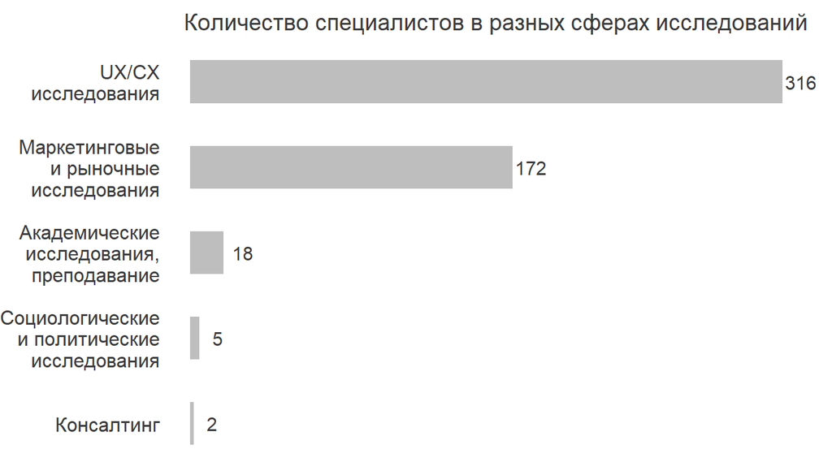

С учетом того, где мы собирали данные, достаточное количество человек набралось в основном в UX/CX-сфере и маркетинговых исследованиях.

Остальные распределения можно посмотреть тут в табличном виде:

**Посмотреть основные распределения**

```
      Тип компании
      Доля



    IT-компании
45%
    Исследовательские и аналитические агентства
20%
    Сфера услуг
17%
    Производство и торговля
8%
    Консалтинг
3%
    Образование
3%
    Фриланс
2%
    Государственные и бюджетные учреждения
2%
    Банки
1%









      Статус исследователя
      Доля



    Независимый исполнитель, фрилансер
3%
    Стажер, практикант
```

[output cut: 88 more lines]

```
0.19%
    Кипр
0.19%
    Аргентина
0.19%
    Австралия
0.19%
    Узбекистан
0.19%
    Хорватия
0.19%
    Приднестровская Молдавская Республика
0.19%
    Кыргызстан
0.19%
```

### Зарплаты по сферам

Если смотреть по сферам исследований, то медианная зарплата больше всего в консалтинге. Но с учетом количества респондентов из этой сферы, на такие данные сложно опираться. Если смотреть на более наполненные ячейки, то мы видим что в UX/CX сфере медианная зарплата немного больше.

[interactive chart not shown]

## Зарплаты по уровню

Дальше мы возьмем две наиболее наполненные сферы исследований и посмотрим, как в них распределяются зарплаты по уровню исследователя.

[interactive chart not shown]

Мы видим небольшую прогрессию медианной зарплаты в зависимости от уровня, что уже неплохо. Но при этом можно заметить, что наибольшее количество аутлаеров у нас находится среди ведущих исследователей. Рок-звезды и в маркетинге и в UX/CX оказались немного более скромными.

## Зарплаты по типу компании

Мне стало интересно, а где у нас находятся эти аутлаеры с миллионными зарплатами, и я решил посмотреть распределение по типу компаний. И здесь мы видим, что чтобы получать больше 1 000 000 в месяц, нужно работать в агентстве или в IT-компании. Но при этом медианная зарплата в IT выше, чем у агентств, так что скорее всего более выгодно идти inhouse-исследователем в IT.

[interactive chart not shown]

## Зарплаты по должности

Здесь мне все же кажется, что важным может быть не только профессиональная самооценка, но и должность, которую человек занимает (удивительно!).

[interactive chart not shown]

И здесь мы видим, что аутлаеры в агентствах появляются в основном за счет генеральных директоров и руководителей компании. То есть если хочется зарабатывать большие деньги в агентстве, то есть резон открывать свое. Если же руководящая должность, но не топ-менеджмент, то лучше в IT.

## Зарплаты по годам опыта

Давайте посмотрим, а насколько сильно зависит уровень зарплаты от опыта.

В принципе, зависимость не явная, но есть. Видно, что линия тренда по линейной модели немножко смотрит вверх. Но в основном это за счет респондентов с менее чем 5 годами опыта. Дальше уже, судя по всему, размер зарплаты зависит не столько от опыта, сколько от умения себя продать.

[interactive chart not shown]

## Количество опыта по профессиональному уровню

Здесь интересно посмотреть в разрезе сфер исследований. Тут мы видим, что да, уровень более-менее зависит от опыта, что славно. Но при этом в UX/CX-исследованиях все же более быстрая прогрессия, чем в маркетинге. Возможно, потому что сфера более молодая.

[interactive chart not shown]

## Как давно повышали

Если смотреть на дату последнего повышения, то мы видим, что большинство респондентов повысили менее чем год назад. Это радостно.

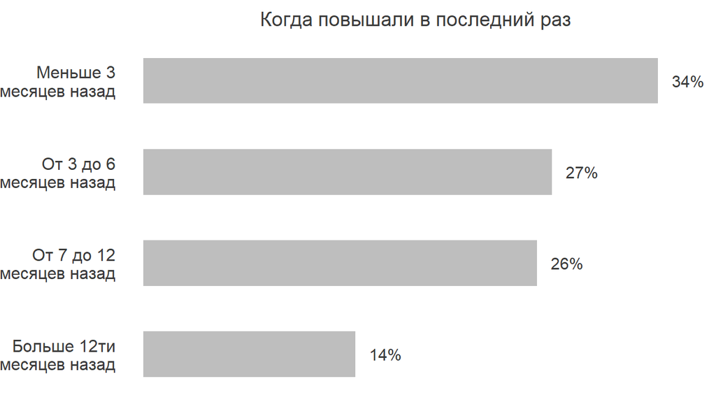

При этом среди причин повышений наиболее частая - это регулярное ревью сотрудников. Возможно это что-то говорит о зрелости нашей HR-культуры.

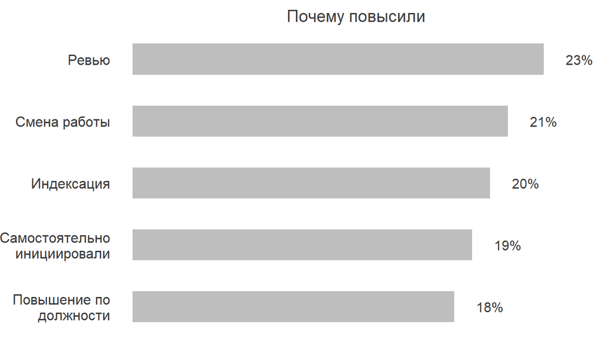

## Насколько сильно повышали

Размер повышения особо не зависит от того, как давно повышали. Значит мы с сильной натяжкой, но все же можем говорить о том, что сильной динамики размера повышений не наблюдается.

[interactive chart not shown]

[interactive chart not shown]

## В заключение

В датасете гораздо больше данных, чем я проанализировал тут. Если вам интересны другие разрезы, или переменные, или перекодировать данные, то вы легко можете скачать почищенные данные [тут](https://uxrozum.github.io/salaryQ32024/salaryQ32024data.xlsx).

По всем вопросам можете писать мне в [телеграм](https://t.me/keycee) или на почту mail@uxrozum.com, спасибо за внимание!